# 《R + Amos + SPSS》

王超

30-07-2026

# 1 方差分析(ANOVA)

【交互式ShinyApps】

- [方差分析原理理解](http://110.40.140.177:3838/ANOVA/ANOVA.Rmd)

## 1.1 单因素方差分析

- 【参考文献】
  - 杨奡偲.基于磁共振定量磁化率成像的阿尔兹海默病脑影像标志物及神经机制研究[D].北京协和医学院,2024.DOI:10.27648/d.cnki.gzxhu.2024.001088.(p101)
- [**One-Way ANOVA**](https://www.statology.org/one-way-anova/)
- [ANOVA is just regression: courses.washington.edu](https://courses.washington.edu/psy524a/_book/anova-is-just-regression.html#anova-as-regression)
- ANOVA & GLM(Univariate) & Linear Regression
- A **one-way ANOVA (“analysis of variance”)** compares the means of **three or more** independent groups to determine if there is a statistically significant difference between the corresponding population means.
- **One-Way ANOVA: Assumptions**(International journals OR Chinese graduate theses)
  - **Normality**
    - The residuals of the model should be approximately normally distributed.
  - **Equal Variances**
    - The variances of the populations that the samples come from are equal.
- Hypothesis
  - Null Hypothesis: All the population means are equal.
  - Alternativr Hypothesis: At least one population mean is different from the rest.
  - Note: If you reject the null hypothesis, this indicates that at least one of the population means is different from the others, but the ANOVA doesn’t specify **which population means are different**. To determine this, you need to perform [post hoc tests](https://www.statology.org/anova-post-hoc-tests/), also known as **multiple comparisons** tests.

【案例数据集】

- DataSet Details:A clinical study was conducted to assess the effect of three formulations of the same drug on reducing cholesterol. The formulations were 20mg at once (1time), 10mg twice a day (2times), and 5mg four times a day (4times). In addition, two competing drugs were used as control group (drugD and drugE). The purpose of the study was to find which of the formulations, if any, is efficacious and how these formulations compare with the existing drugs.
- 单因素方差分析案例数据集链接

【操作视频】

- 单因素方差分析操作视频链接

【结果呈现】

- 结果汇报推荐格式

## 1.2 协方差分析

- 【参考文献】
  - SAQ训练法对11-13岁青少年短跑运动员身体素质的影响研究(p33)
- Analysis of covariance (**ANCOVA**) is a statistical procedure that combines features of analysis of variance (ANOVA) and linear regression. It is designed to test for differences between two or more group means on a dependent variable (Y) after statistically controlling for the effects of one or more continuous nuisance variables, referred to as covariates (X).
- The primary rationale for ANCOVA is twofold: (1) to reduce error variance by accounting for variability in Y that is attributable to the covariate, thereby increasing the statistical power of the test for group differences; and (2) to adjust for preexisting differences between groups on variables that would otherwise confound the relationship between group membership (the independent variable) and the outcome Y. This adjustment is particularly valuable in **quasi-experimental designs where random assignment to groups is not possible**, or in randomized experiments where chance **baseline imbalances** occur despite randomization.
- 基于“残差”的剥离机制
  - 建立基线回归（剥离协变量W的影响）
    - $\hat{Y}= b_{0} + b_{1} W$
  - 提取“纯净”的回归残差
    - $e_{i}= Y_{i}- \hat{Y_{i}}$
  - 对残差进行方差分析（ANOVA）
- Hypothesis
  - **Homogeneity of Regression Slopes**:The slope of the linear regression of the dependent variable Y on the covariate X is identical across all comparison groups. Violation of this assumption indicates that the magnitude of the group difference varies as a function of the covariate, making the standard adjusted mean comparison uninterpretable.

【案例数据集】

- 协方差分析-斜率齐性案例数据集链接
- 协方差分析-斜率不齐案例数据集链接

【操作视频】

- 协方差分析-斜率齐性操作视频链接
- 协方差分析-斜率不齐操作视频链接

【结果呈现】

- 结果汇报推荐格式-斜率齐性
- 结果汇报推荐格式-斜率不齐

## 1.3 双因素方差分析

【参考文献】

- 陈艾凡.基于自我管理支持的综合核心干预对社区老年2型糖尿病患者血糖控制效果影响的随机对照研究[D].福建医科大学,2021.DOI:10.27020/d.cnki.gfjyu.2021.000443.
- [1]袁昊炜.脊髓损伤患者认知强化综合干预模式的实证研究[D].安徽医科大学,2023.DOI:10.26921/d.cnki.ganyu.2023.001770.

A **two-way ANOVA** is used to determine whether or not there is a statistically significant difference between the means of three or more independent groups that have been split on two factors.

The purpose of a two-way ANOVA is to determine how two factors impact a response variable, and to determine whether or not there is an **interaction** between the two factors on the response variable.

[Estimated Marginal Means](https://www.statology.org/marginal-mean/)

【案例数据集】

- The response is the length of odontoblasts (cells responsible for tooth growth) in 60 guinea pigs. Each animal received one of three dose levels of vitamin C (0.5, 1, and 2 mg/day) by one of two delivery methods, orange juice or ascorbic acid (a form of vitamin C and coded as VC).
- 双因素方差分析案例数据集链接

【操作视频】

- 双因素方差分析操作视频链接

【结果呈现】

- 结果汇报推荐格式
- 【基于R语言与SPSS的双因素(单独效应)方差分析过程及可视化效果对比】

## 1.4 混合模型方差分析

Mixed ANOVA (Mixed-design Analysis of Variance) is a statistical method that analyzes data from experimental designs combining:

- Between-subjects factors (independent groups, e.g., Treatment vs. Control).
- Within-subjects factors (repeated measures, e.g., Time points or conditions).

It partitions variance into:

- Between-groups effects (differences across independent groups).
- Within-subjects effects (changes over repeated measurements).
- Interaction effects (how group differences vary across repeated conditions).

Interaction Effect:

- An interaction effect occurs when the effect of one factor (e.g., a between-subjects factor) on the response variable depends on the level of another factor (e.g., a within-subjects factor).
- In a mixed-design ANOVA, a significant interaction indicates that the pattern of change across repeated measurements differs between groups.
- “An interaction effect focuses **not on whether differences exist**, but **on whether those differences change across conditions**.”

Assumptions:

- Sphericity (for within-subjects effects): Sphericity refers to the assumption that the variances of the differences between all pairs of levels of a within-subjects factor are equal.
  - Null Hypothesis: The data meet the sphericity assumption (equal variances of all pairwise differences).
  - Alternative Hypothesis: The data violate the sphericity assumption (at least one pair of difference variances is unequal).
- Mauchly’s Test of Sphericity
  - Mauchly’s test indicated that the assumption of sphericity was met (p > .05); therefore, uncorrected degrees of freedom were used for the within-subjects effects.
  - Mauchly’s test indicated that the assumption of sphericity was violated (p < .05). Therefore, Greenhouse–Geisser corrected degrees of freedom were applied (ε = …).

[Estimated Marginal Means](https://www.statology.org/marginal-mean/)

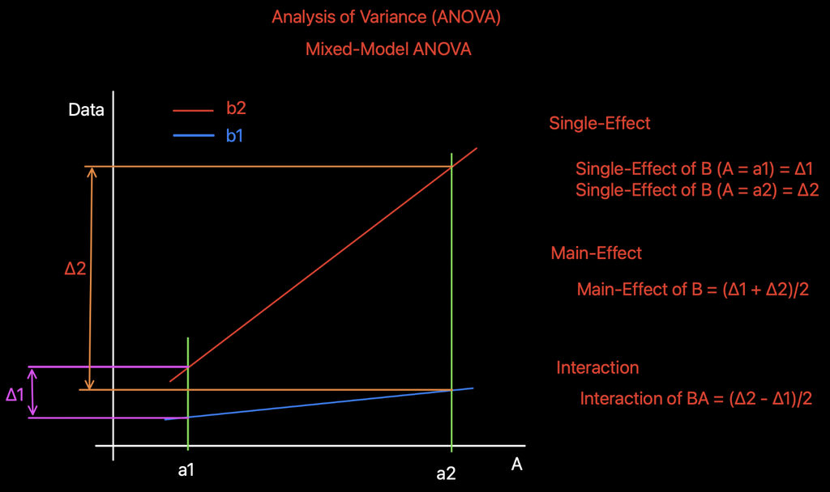

Mixed-Model ANOVA，参考《医学统计学》p176

【参考文献】

- 刘日.慢性胰腺炎胰管结石临床影像学研究及纤维化分子影像初探[D].中国人民解放军海军军医大学,2019.(P50)
- 王彩卉.高强度环境光照对大学生情绪状态的影响及其生理特征[D].上海体育大学,2024.DOI:10.27315/d.cnki.gstyx.2024.000363.(规范性?!,P15-)
  - (APA)Publication Manual of the American Psychological Association
    - d: Cohen’s d
    - MD: Mean Diff
- EM Means

【案例数据集】

- 重复测量方差分析案例数据集链接
- 混合模型方差分析案例数据集链接

【操作视频】

- 重复测量方差分析操作视频链接
- 混合模型方差分析操作视频链接

【结果呈现】

- 结果汇报推荐格式